# SN_02_DOA_RECIP_ADDR_L1

Recipient street address line 1 · Text report

## Overview

**Description**

Foreign Address - AddressLine1

**Table**

`SN-P02-T01-DISPOSITION-OF-ASSETS` (many)

**Location code**

`SCHED-N-PART-02-LINE-01-COL-F`

**Family**

`SCHED-N-PART-02-LINE-01-COL-F` · siblings: SN_02_DOA_RECIP_ADDR_CITY , SN_02_DOA_RECIP_ADDR_CNTR, SN_02_DOA_RECIP_ADDR_L2, SN_02_DOA_RECIP_ADDR_STATE, SN_02_DOA_RECIP_ADDR_ZIP, SN_02_DOA_RECIP_NAME_ORG_L1

**Data type**

text (xsd: StreetAddressType, )

**Scope**

PZ

**Status**

unreviewed

8

xpaths mapped (6 observed)

15,051

filings with a value

2009–2024

tax years observed

8

open flags (1 errors)

## Flags

| Severity | Flag | Xpath | Detail |
| --- | --- | --- | --- |
| ⚠ error | `COLLISION` | IRS990ScheduleN/DispositionOfAssetsDetail/ForeignAddress/AddressLine1Txt | 33 filings contain 2+ of its xpaths; most common set: /Return/ReturnData/IRS990ScheduleN/DispositionOfAssetsDetail/ForeignAddress/AddressLine1Txt ; /Return/ReturnData/IRS990ScheduleN/DispositionOfAsse… |
| ⓘ info | `MANY_NOT_REPEATING` | IRS990ScheduleN/DispositionOfAssetsDetail/USAddress/AddressLine1Txt | many-to-one table, but 72% of values sit in no repeating element |
| ⓘ info | `MANY_NOT_REPEATING` | IRS990ScheduleN/DispositionTable/AddressUS/AddressLine1 | many-to-one table, but 73% of values sit in no repeating element |
| ⓘ info | `MANY_NOT_REPEATING` | IRS990ScheduleN/DispositionOfAssetsDetail/USAddress/AddressLine1 | many-to-one table, but 70% of values sit in no repeating element |
| ⓘ info | `MANY_NOT_REPEATING` | IRS990ScheduleN/DispositionOfAssetsDetail/ForeignAddress/AddressLine1Txt | many-to-one table, but 59% of values sit in no repeating element |
| ⓘ info | `MANY_NOT_REPEATING` | IRS990ScheduleN/DispositionTable/AddressForeign/AddressLine1 | many-to-one table, but 53% of values sit in no repeating element |
| ⓘ info | `UNOBSERVED` | IRS990ScheduleN/Form990ScheduleNPartII/DispositionTable/AddressForeign/AddressLine1 | never observed in TY2009-2024 filings |
| ⓘ info | `UNOBSERVED` | IRS990ScheduleN/Form990ScheduleNPartII/DispositionTable/AddressUS/AddressLine1 | never observed in TY2009-2024 filings |

## Xpaths

All mapped xpaths (under /Return/ReturnData or /Return/ReturnHeader), oldest first. Charts label each series by its xpath.

| Xpath | Form | Chart label | First year | Last year | Versions | Filings | Repeats in |
| --- | --- | --- | --- | --- | --- | --- | --- |
| IRS990ScheduleN/DispositionTable/AddressUS/AddressLine1 | Sched N | same | 2009 | 2012 | 16 | 2,276 | 26.4% |
| IRS990ScheduleN/DispositionTable/AddressForeign/AddressLine1 | Sched N | same | 2009 | 2012 | 9 | 38 | 34.2% |
| IRS990ScheduleN/DispositionOfAssetsDetail/USAddress/AddressLine1 | Sched N | …cheduleN/DispositionOfAssetsDetail/USAddress/AddressLine1 | 2013 | 2013 | 3 | 868 | 29.4% |
| IRS990ScheduleN/DispositionOfAssetsDetail/ForeignAddress/AddressLine1 | Sched N | …leN/DispositionOfAssetsDetail/ForeignAddress/AddressLine1 | 2013 | 2013 | 3 | 15 | 40.0% |
| IRS990ScheduleN/DispositionOfAssetsDetail/USAddress/AddressLine1Txt | Sched N | …duleN/DispositionOfAssetsDetail/USAddress/AddressLine1Txt | 2014 | 2024 | 34 | 11,669 | 27.2% |
| IRS990ScheduleN/DispositionOfAssetsDetail/ForeignAddress/AddressLine1Txt | Sched N | …/DispositionOfAssetsDetail/ForeignAddress/AddressLine1Txt | 2014 | 2024 | 28 | 185 | 32.4% |
| IRS990ScheduleN/Form990ScheduleNPartII/DispositionTable/AddressForeign/AddressLine1 | Sched N | …eduleNPartII/DispositionTable/AddressForeign/AddressLine1 |  |  |  | 0 |  |
| IRS990ScheduleN/Form990ScheduleNPartII/DispositionTable/AddressUS/AddressLine1 | Sched N | …90ScheduleNPartII/DispositionTable/AddressUS/AddressLine1 |  |  |  | 0 |  |

## Coverage

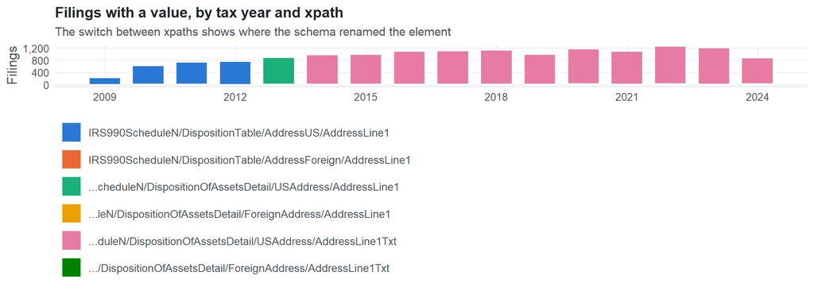

**Table view**

Table view: filings by tax year and series

| Tax year | IRS990ScheduleN/DispositionTable/AddressUS/AddressLine1 | IRS990ScheduleN/DispositionTable/AddressForeign/AddressLine1 | …cheduleN/DispositionOfAssetsDetail/USAddress/AddressLine1 | …leN/DispositionOfAssetsDetail/ForeignAddress/AddressLine1 | …duleN/DispositionOfAssetsDetail/USAddress/AddressLine1Txt | …/DispositionOfAssetsDetail/ForeignAddress/AddressLine1Txt |
| --- | --- | --- | --- | --- | --- | --- |
| 2009 | 211 | 4 | 0 | 0 | 0 | 0 |
| 2010 | 606 | 15 | 0 | 0 | 0 | 0 |
| 2011 | 713 | 11 | 0 | 0 | 0 | 0 |
| 2012 | 746 | 8 | 0 | 0 | 0 | 0 |
| 2013 | 0 | 0 | 868 | 15 | 0 | 0 |
| 2014 | 0 | 0 | 0 | 0 | 964 | 13 |
| 2015 | 0 | 0 | 0 | 0 | 969 | 12 |
| 2016 | 0 | 0 | 0 | 0 | 1,082 | 10 |
| 2017 | 0 | 0 | 0 | 0 | 1,079 | 19 |
| 2018 | 0 | 0 | 0 | 0 | 1,118 | 11 |
| 2019 | 0 | 0 | 0 | 0 | 978 | 11 |
| 2020 | 0 | 0 | 0 | 0 | 1,139 | 24 |
| 2021 | 0 | 0 | 0 | 0 | 1,073 | 16 |
| 2022 | 0 | 0 | 0 | 0 | 1,231 | 26 |
| 2023 | 0 | 0 | 0 | 0 | 1,186 | 20 |
| 2024 | 0 | 0 | 0 | 0 | 850 | 23 |

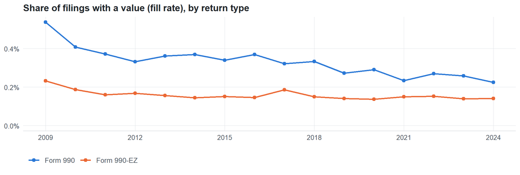

**Table view**

Table view: fill rate

| Tax year | Return type | Filings | All filings | Fill rate |
| --- | --- | --- | --- | --- |
| 2009 | Form 990 | 179 | 33,311 | 0.54% |
| 2009 | Form 990-EZ | 36 | 15,470 | 0.23% |
| 2010 | Form 990 | 502 | 123,025 | 0.41% |
| 2010 | Form 990-EZ | 119 | 63,326 | 0.19% |
| 2011 | Form 990 | 593 | 159,504 | 0.37% |
| 2011 | Form 990-EZ | 131 | 82,048 | 0.16% |
| 2012 | Form 990 | 597 | 179,688 | 0.33% |
| 2012 | Form 990-EZ | 157 | 93,750 | 0.17% |
| 2013 | Form 990 | 720 | 198,855 | 0.36% |
| 2013 | Form 990-EZ | 163 | 104,375 | 0.16% |
| 2014 | Form 990 | 808 | 218,619 | 0.37% |
| 2014 | Form 990-EZ | 169 | 116,417 | 0.15% |
| 2015 | Form 990 | 792 | 233,519 | 0.34% |
| 2015 | Form 990-EZ | 189 | 124,894 | 0.15% |
| 2016 | Form 990 | 902 | 243,903 | 0.37% |
| 2016 | Form 990-EZ | 190 | 130,484 | 0.15% |
| 2017 | Form 990 | 840 | 261,612 | 0.32% |
| 2017 | Form 990-EZ | 258 | 139,144 | 0.19% |
| 2018 | Form 990 | 906 | 271,442 | 0.33% |
| 2018 | Form 990-EZ | 223 | 149,384 | 0.15% |
| 2019 | Form 990 | 774 | 283,694 | 0.27% |
| 2019 | Form 990-EZ | 215 | 152,622 | 0.14% |
| 2020 | Form 990 | 930 | 320,342 | 0.29% |
| 2020 | Form 990-EZ | 233 | 169,864 | 0.14% |
| 2021 | Form 990 | 786 | 336,480 | 0.23% |
| 2021 | Form 990-EZ | 303 | 202,724 | 0.15% |
| 2022 | Form 990 | 942 | 349,055 | 0.27% |
| 2022 | Form 990-EZ | 315 | 206,130 | 0.15% |
| 2023 | Form 990 | 917 | 354,768 | 0.26% |
| 2023 | Form 990-EZ | 289 | 206,379 | 0.14% |
| 2024 | Form 990 | 622 | 277,298 | 0.22% |
| 2024 | Form 990-EZ | 251 | 178,867 | 0.14% |

## Repeating groups

Table cardinality in the concordance: **many**. 6 of 6 observed xpaths repeat within a filing.

Repeating element each xpath was observed in (from the raw indexed xpath)

| Xpath | Repeating element | Filings (summed over years) |
| --- | --- | --- |
| IRS990ScheduleN/DispositionTable/AddressForeign/AddressLine1 | (none) | 20 |
| IRS990ScheduleN/DispositionTable/AddressForeign/AddressLine1 | IRS990ScheduleN/DispositionTable | 18 |
| IRS990ScheduleN/DispositionTable/AddressUS/AddressLine1 | (none) | 1656 |
| IRS990ScheduleN/DispositionTable/AddressUS/AddressLine1 | IRS990ScheduleN/DispositionTable | 620 |
| IRS990ScheduleN/DispositionOfAssetsDetail/ForeignAddress/AddressLine1 | (none) | 7 |
| IRS990ScheduleN/DispositionOfAssetsDetail/ForeignAddress/AddressLine1 | IRS990ScheduleN/DispositionOfAssetsDetail | 8 |
| IRS990ScheduleN/DispositionOfAssetsDetail/USAddress/AddressLine1 | (none) | 607 |
| IRS990ScheduleN/DispositionOfAssetsDetail/USAddress/AddressLine1 | IRS990ScheduleN/DispositionOfAssetsDetail | 261 |
| IRS990ScheduleN/DispositionOfAssetsDetail/ForeignAddress/AddressLine1Txt | (none) | 110 |
| IRS990ScheduleN/DispositionOfAssetsDetail/ForeignAddress/AddressLine1Txt | IRS990ScheduleN/DispositionOfAssetsDetail | 75 |
| IRS990ScheduleN/DispositionOfAssetsDetail/USAddress/AddressLine1Txt | (none) | 8409 |
| IRS990ScheduleN/DispositionOfAssetsDetail/USAddress/AddressLine1Txt | IRS990ScheduleN/DispositionOfAssetsDetail | 3260 |

## Values

| Result | Check | Detail |
| --- | --- | --- |
| ✓ pass | Values are text, not numbers | 0% of values are numeric |
| ⓘ info | No sign of truncation | …leN/DispositionOfAssetsDetail/ForeignAddress/AddressLine1: longest value is exactly 35 characters; …/DispositionOfAssetsDetail/ForeignAddress/AddressLine1Txt: longest value is exactly 35 characters; … |
| ✓ pass | No dominant boilerplate value | most common value covers 8% of filings: “99 GREAT RUSSELL STREET” |

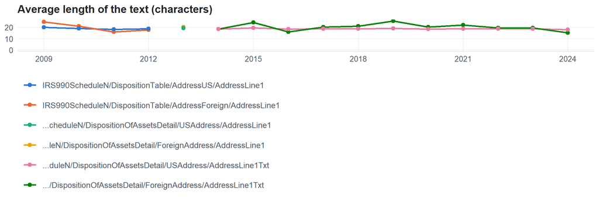

**Table view**

Table view: length and variety by tax year

| Series | Tax year | Filings | Avg length | Max length | Distinct values (approx.) |
| --- | --- | --- | --- | --- | --- |
| IRS990ScheduleN/DispositionTable/AddressUS/AddressLine1 | 2009 | 211 | 20 | 34 | 166 |
| IRS990ScheduleN/DispositionTable/AddressUS/AddressLine1 | 2010 | 606 | 19 | 35 | 430 |
| IRS990ScheduleN/DispositionTable/AddressUS/AddressLine1 | 2011 | 713 | 18 | 34 | 395 |
| IRS990ScheduleN/DispositionTable/AddressUS/AddressLine1 | 2012 | 746 | 19 | 35 | 467 |
| IRS990ScheduleN/DispositionTable/AddressForeign/AddressLine1 | 2009 | 4 | 25 | 28 | 5 |
| IRS990ScheduleN/DispositionTable/AddressForeign/AddressLine1 | 2010 | 15 | 21 | 28 | 7 |
| IRS990ScheduleN/DispositionTable/AddressForeign/AddressLine1 | 2011 | 11 | 16 | 28 | 7 |
| IRS990ScheduleN/DispositionTable/AddressForeign/AddressLine1 | 2012 | 8 | 18 | 27 | 7 |
| …cheduleN/DispositionOfAssetsDetail/USAddress/AddressLine1 | 2013 | 868 | 19 | 35 | 355 |
| …leN/DispositionOfAssetsDetail/ForeignAddress/AddressLine1 | 2013 | 15 | 20 | 35 | 9 |
| …duleN/DispositionOfAssetsDetail/USAddress/AddressLine1Txt | 2014 | 964 | 18 | 35 | 458 |
| …duleN/DispositionOfAssetsDetail/USAddress/AddressLine1Txt | 2015 | 969 | 19 | 34 | 622 |
| …duleN/DispositionOfAssetsDetail/USAddress/AddressLine1Txt | 2016 | 1,082 | 19 | 35 | 832 |
| …duleN/DispositionOfAssetsDetail/USAddress/AddressLine1Txt | 2017 | 1,079 | 19 | 35 | 698 |
| …duleN/DispositionOfAssetsDetail/USAddress/AddressLine1Txt | 2018 | 1,118 | 19 | 34 | 786 |
| …duleN/DispositionOfAssetsDetail/USAddress/AddressLine1Txt | 2019 | 978 | 19 | 35 | 409 |
| …duleN/DispositionOfAssetsDetail/USAddress/AddressLine1Txt | 2020 | 1,139 | 18 | 35 | 580 |
| …duleN/DispositionOfAssetsDetail/USAddress/AddressLine1Txt | 2021 | 1,073 | 19 | 35 | 653 |
| …duleN/DispositionOfAssetsDetail/USAddress/AddressLine1Txt | 2022 | 1,231 | 19 | 35 | 1,472 |
| …duleN/DispositionOfAssetsDetail/USAddress/AddressLine1Txt | 2023 | 1,186 | 19 | 35 | 474 |
| …duleN/DispositionOfAssetsDetail/USAddress/AddressLine1Txt | 2024 | 850 | 18 | 35 | 416 |
| …/DispositionOfAssetsDetail/ForeignAddress/AddressLine1Txt | 2014 | 13 | 19 | 32 | 13 |
| …/DispositionOfAssetsDetail/ForeignAddress/AddressLine1Txt | 2015 | 12 | 24 | 29 | 5 |
| …/DispositionOfAssetsDetail/ForeignAddress/AddressLine1Txt | 2016 | 10 | 16 | 28 | 6 |
| …/DispositionOfAssetsDetail/ForeignAddress/AddressLine1Txt | 2017 | 19 | 20 | 29 | 20 |
| …/DispositionOfAssetsDetail/ForeignAddress/AddressLine1Txt | 2018 | 11 | 21 | 29 | 9 |
| …/DispositionOfAssetsDetail/ForeignAddress/AddressLine1Txt | 2019 | 11 | 26 | 33 | 5 |
| …/DispositionOfAssetsDetail/ForeignAddress/AddressLine1Txt | 2020 | 24 | 20 | 35 | 9 |
| …/DispositionOfAssetsDetail/ForeignAddress/AddressLine1Txt | 2021 | 16 | 22 | 33 | 7 |
| …/DispositionOfAssetsDetail/ForeignAddress/AddressLine1Txt | 2022 | 26 | 20 | 34 | 16 |
| …/DispositionOfAssetsDetail/ForeignAddress/AddressLine1Txt | 2023 | 20 | 19 | 33 | 10 |
| …/DispositionOfAssetsDetail/ForeignAddress/AddressLine1Txt | 2024 | 23 | 15 | 30 | 10 |

Most common values by xpath (all years; long values truncated)

| Series | Value | Filings | Share |
| --- | --- | --- | --- |
| IRS990ScheduleN/DispositionTable/AddressUS/AddressLine1 | 1401 HAMPTON AVENUE | 19 | 0.8% |
| IRS990ScheduleN/DispositionTable/AddressUS/AddressLine1 | 2021 N MCCORD ROAD | 11 | 0.5% |
| IRS990ScheduleN/DispositionTable/AddressUS/AddressLine1 | 4000 MERIDIAN BLVD | 10 | 0.4% |
| IRS990ScheduleN/DispositionTable/AddressUS/AddressLine1 | 222 SOUTH FIRST ST | 8 | 0.4% |
| IRS990ScheduleN/DispositionTable/AddressUS/AddressLine1 | 5430 WEST HIGHWAY 40 | 8 | 0.4% |
| IRS990ScheduleN/DispositionTable/AddressUS/AddressLine1 | PO Box 650311 M/S 3905 | 7 | 0.3% |
| IRS990ScheduleN/DispositionTable/AddressUS/AddressLine1 | 2335 NORTH BANK DRIVE | 6 | 0.3% |
| IRS990ScheduleN/DispositionTable/AddressUS/AddressLine1 | 101 E State Street | 6 | 0.3% |
| IRS990ScheduleN/DispositionTable/AddressUS/AddressLine1 | 6735 TELEGRAPH ROAD | 6 | 0.3% |
| IRS990ScheduleN/DispositionTable/AddressUS/AddressLine1 | 1401 HAMPTON AVE | 6 | 0.3% |
| IRS990ScheduleN/DispositionTable/AddressUS/AddressLine1 | 200 BLOUNT AVENUE SUITE 600 | 5 | 0.2% |
| IRS990ScheduleN/DispositionTable/AddressUS/AddressLine1 | 101 California St 26th Floor | 5 | 0.2% |
| IRS990ScheduleN/DispositionTable/AddressUS/AddressLine1 | 70 East Street | 4 | 0.2% |
| IRS990ScheduleN/DispositionTable/AddressUS/AddressLine1 | 4000 MacArthur Blvd | 4 | 0.2% |
| IRS990ScheduleN/DispositionTable/AddressUS/AddressLine1 | PO BOX 403008 | 4 | 0.2% |
| IRS990ScheduleN/DispositionTable/AddressUS/AddressLine1 | 100 NORTH ACADEMY AVENUE MC 49-70 | 4 | 0.2% |
| IRS990ScheduleN/DispositionTable/AddressUS/AddressLine1 | 104 WEST 40TH STREET | 4 | 0.2% |
| IRS990ScheduleN/DispositionTable/AddressUS/AddressLine1 | 900 HOPE WAY | 4 | 0.2% |
| IRS990ScheduleN/DispositionTable/AddressUS/AddressLine1 | 14528 SOUTH OUTER 30 ROAD SUITE 10 | 3 | 0.1% |
| IRS990ScheduleN/DispositionTable/AddressUS/AddressLine1 | 1999 broadway suite 1000 | 3 | 0.1% |
| IRS990ScheduleN/DispositionTable/AddressUS/AddressLine1 | 750 FULLER AVE NE - MC 160 | 3 | 0.1% |
| IRS990ScheduleN/DispositionTable/AddressUS/AddressLine1 | 20 York Street | 3 | 0.1% |
| IRS990ScheduleN/DispositionTable/AddressUS/AddressLine1 | 3663 South Miami Avenue | 3 | 0.1% |
| IRS990ScheduleN/DispositionTable/AddressUS/AddressLine1 | 2969 LOCUST LANE | 3 | 0.1% |
| IRS990ScheduleN/DispositionTable/AddressUS/AddressLine1 | PO BOX 750261 | 3 | 0.1% |
| IRS990ScheduleN/DispositionTable/AddressUS/AddressLine1 | 125 CRESTRIDGE STREET | 2 | 0.1% |
| IRS990ScheduleN/DispositionTable/AddressUS/AddressLine1 | 1300 NORTH 17TH AVENUE | 2 | 0.1% |
| IRS990ScheduleN/DispositionTable/AddressUS/AddressLine1 | 1415 W White Oak Street | 2 | 0.1% |
| IRS990ScheduleN/DispositionTable/AddressUS/AddressLine1 | 1701 P Street | 2 | 0.1% |
| IRS990ScheduleN/DispositionTable/AddressUS/AddressLine1 | 211 WEST MAIN | 2 | 0.1% |

First rows shown.

## Examples

| Tax year | Return | Xpath | Organization | Value | Source |
| --- | --- | --- | --- | --- | --- |
| 2024 | 990 | IRS990ScheduleN/DispositionOfAssetsDetail/ForeignAddress/AddressLine1Txt | DECENTRALIZED PICTURES FOUNDATION INC | POSTSTRASSE 30 | [XML](https://gt990datalake-rawdata.s3.amazonaws.com/EfileData/XmlFiles/202543219349313599_public.xml) |
| 2024 | 990EZ | IRS990ScheduleN/DispositionOfAssetsDetail/USAddress/AddressLine1Txt | OPTOMETRIC COUNCIL ON REFRACTIVE TECHNOLOGY INC | 925 S SEMORAN BLVD STE 120 | [XML](https://gt990datalake-rawdata.s3.amazonaws.com/EfileData/XmlFiles/202520519349200212_public.xml) |
| 2023 | 990 | IRS990ScheduleN/DispositionOfAssetsDetail/ForeignAddress/AddressLine1Txt | NEW GENERATION FOUNDATION INC | 100 XX | [XML](https://gt990datalake-rawdata.s3.amazonaws.com/EfileData/XmlFiles/202413209349327251_public.xml) |
| 2023 | 990 | IRS990ScheduleN/DispositionOfAssetsDetail/USAddress/AddressLine1Txt | PCPT HAMLIN LLC | 333 S GARLAND AVENUE - STE 130 | [XML](https://gt990datalake-rawdata.s3.amazonaws.com/EfileData/XmlFiles/202413189349305896_public.xml) |
| 2022 | 990 | IRS990ScheduleN/DispositionOfAssetsDetail/ForeignAddress/AddressLine1Txt | FUTURE OF LIFE INSTITUTE | 12 RUE DE CORBUSIER 771 | [XML](https://gt990datalake-rawdata.s3.amazonaws.com/EfileData/XmlFiles/202510309349301606_public.xml) |
| 2022 | 990 | IRS990ScheduleN/DispositionOfAssetsDetail/USAddress/AddressLine1Txt | SEATTLE FULL GOSPEL CHURCH | 1037 NE 65TH ST 82191 | [XML](https://gt990datalake-rawdata.s3.amazonaws.com/EfileData/XmlFiles/202541769349300919_public.xml) |
| 2021 | 990EZ | IRS990ScheduleN/DispositionOfAssetsDetail/ForeignAddress/AddressLine1Txt | PET Florida Tampa | Plot No 1 | [XML](https://gt990datalake-rawdata.s3.amazonaws.com/EfileData/XmlFiles/202201089349202500_public.xml) |
| 2021 | 990 | IRS990ScheduleN/DispositionOfAssetsDetail/USAddress/AddressLine1Txt | GREENWATCH INSTITUTE | 100 W 10TH ST | [XML](https://gt990datalake-rawdata.s3.amazonaws.com/EfileData/XmlFiles/202203149349305270_public.xml) |
| 2020 | 990 | IRS990ScheduleN/DispositionOfAssetsDetail/ForeignAddress/AddressLine1Txt | GREEN BUSINESS CERTIFICATION INC | BARBARA STROZZILAAN 101 | [XML](https://gt990datalake-rawdata.s3.amazonaws.com/EfileData/XmlFiles/202303469349300405_public.xml) |
| 2020 | 990 | IRS990ScheduleN/DispositionOfAssetsDetail/USAddress/AddressLine1Txt | MORGAN STANLEY GLOBAL IMPACT FUNDING | 8910 PURDUE ROAD | [XML](https://gt990datalake-rawdata.s3.amazonaws.com/EfileData/XmlFiles/202123219349301552_public.xml) |
| 2019 | 990 | IRS990ScheduleN/DispositionOfAssetsDetail/ForeignAddress/AddressLine1Txt | THE AMERICAN FRIENDS OF THE WHITECHAPEL GALLERY FOUNDATIONINC | 77-82 WHITECHAPEL HIGH DTREET | [XML](https://gt990datalake-rawdata.s3.amazonaws.com/EfileData/XmlFiles/202100089349302105_public.xml) |
| 2019 | 990 | IRS990ScheduleN/DispositionOfAssetsDetail/USAddress/AddressLine1Txt | SILICON VALLEY FORUM | 101 W SANTA CLARA ST | [XML](https://gt990datalake-rawdata.s3.amazonaws.com/EfileData/XmlFiles/202013469349301316_public.xml) |

## Reviewer checklist

- The definition matches the form line and instructions for every xpath’s schema years.
- Every xpath pooled here measures the same thing on the 990 and 990-EZ (close enough for analysis).
- The coverage chart has no unexplained gaps or jumps between tax years.
- Each open flag is fixed, or accepted with a note in validation_log.csv.
- Values answer the question on the form line (not another line’s explanation).
- Boilerplate such as ‘See Schedule O’ or ‘N/A’ is expected here, or should be treated as missing.
- Text that is really a number or a code is flagged for a different data type.

Record the review as a row in `inst/extdata/src/validation_log.csv` (variable_name, reviewer, date, status, note). Evidence built 2026-09-23 17:09:04 MST from the ef2 DuckDB builds (tax years 2009–2024).